# Part II - An analysis of features which have the most influence of Loan Outcomes.

## by Oludare Adekunle

## Investigation Overview

> The aim of this project is to investigate how various factors influence loan outcomes listed in the loan status column. This could aid determine what factors must be considered before issuing a loan as they will increase the loan completion performance.

## Dataset Overview

> Loan Data from Prosper: This data set contains 113,937 loans with 81 variables on each loan, including loan amount, borrower rate (or interest rate), current loan status, borrower income, and many others. Of these I selected a subset of 23 features and Loan status column. Of the subset a smaller subset of loan status, employment status, listing category, borrower rates and howeowners are used as they show lage variations across the factors being observed, Loan status.

## Distribution across all states of the loan status.

> The chart below shows the distribution of various loan states of observations in the dataset.

> From the plot chart above we can see that the out if the current observations in the data, 50% are currently under a type of loan, 33% completed the loan, while 17% belond to some state of defaulted, charged off or past due.

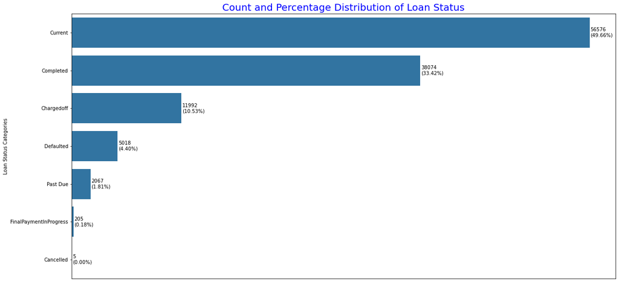

## Distribution of borrower rate across loan status.

> The plot below shows the median borrower rate while the width of each violin shows consentration of borrowers around the borrower rate.

> From the plot we can see that most borrowers in the completed category are concentrated around the lower borrower rates (less than the median rate), while borrowers who defaulted have a higher median borrower rate and are concentrated around the higher borrower rates

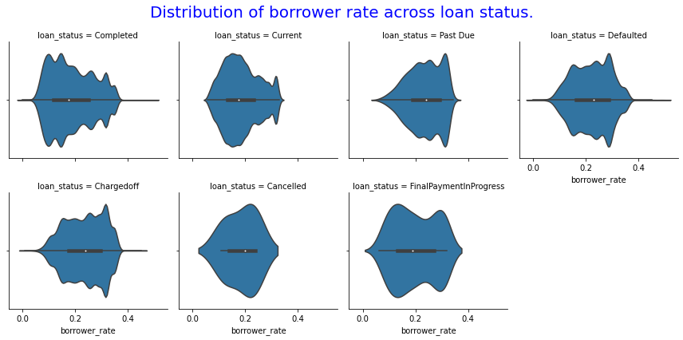

## Distribution of Employment Status across loan Status.

> This plot shows the various states of employment and how they perform on loans borrowed. Below are the findings from this exploration.

> The employed status has the most observations. Furthermore, when we look at the diffent states of employed recorded, we see that part-time have the best loan completion self-employed and full-time.

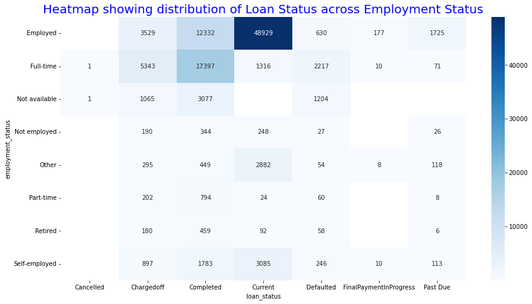

## Distribution of Loan listings across loan Status.

> This plot shows how the various reasons for which loans are borrowed and how the turn out across those reasons. Below are the insights from exploring the data

> In almost all loan status category, we see that the reason for which our observation access loans the most is for debt consolidation. However, when we look at the defaulted category where we expect to find similar trend of debt consolidation topping the list we find that, observations where there is no record of what the loan is used for tops the chart.

> Observations for which we have no record of what they were used for, also takes the lead in the loans that have been charged off.

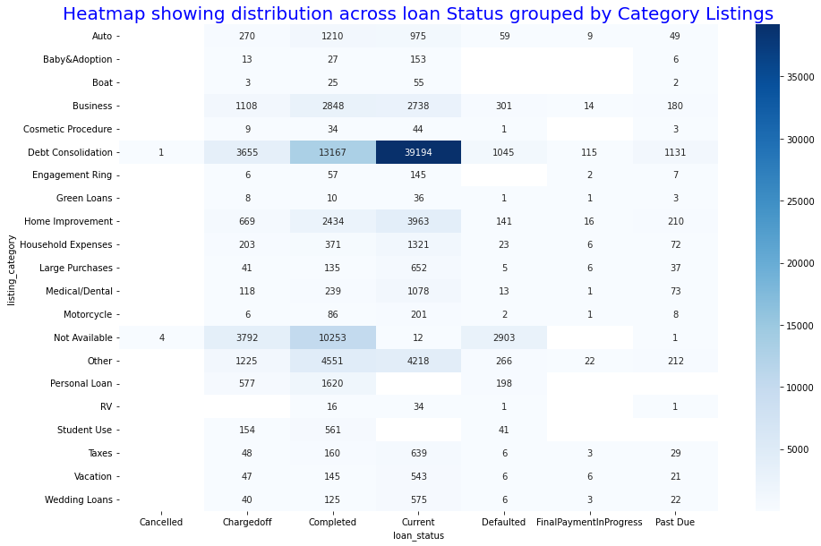

## Borrower rates on loan status for home owners against non home owners

> Generally, there is a less borrower rate for home-owners.

> Regardess of home-owner status, low borrower rate tends plays a role in enabling completion of loan status.

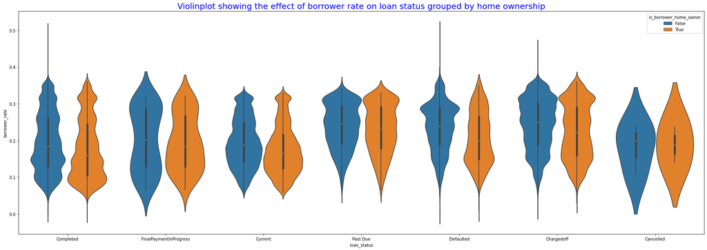